# ALTERNATIVE ASSIGNMENT 2022/2023: Interpreting statistical results

# Task description

Below you will find some outputs from a statistical analysis undertaken using data from the Understanding Society survey (Wave 11). This is the same dataset we used in class and the outputs should be familiar from the worksheets. To prepare for the task, you should revisit the IT lab worksheets from weeks 6 to 9.

Your task is to interpret the findings as completely as you can in the format of a brief report (max. 1,000 words). The outputs contain some information about the variables included in the analysis, but to gain a more complete understanding of where the data came from and how the variables were measured you should also engage with the survey’s webpage, particularly the variable search function. In your report, briefly cover the following aspects:

1. What do the variables included in the analysis measure?
2. Are the chosen variables useful for answering the stated research question? Why so, or why not? What are their limitations?
3. Interpret the relevant statistical results shown in the output tables.
4. Provide a brief narrative paragraph on how you would answer the stated research question based on the statistical findings.

# Statistical results

The outputs below are from an analysis attempting to answer the following research question using data from the Understanding Society Survey:

> Does being in paid employment improve subjective wellbeing?

The following outputs were produced in the process of addressing the question empirically.

### Descriptive statistics

The `ukhls` dataset was reduced to the following four variables:

```r
summary(ukhls)
```

```
   scghq1_dv      employ          age_dv                     hiqual_dv
 Min.   : 0.00   Yes :21276   Min.   : 16.00   Degree             :10058
 1st Qu.: 7.00   No  :16263   1st Qu.: 34.00   Other higher degree: 4659
 Median :10.00   NA's: 1754   Median : 49.00   A-level etc        : 8326
 Mean   :11.12                Mean   : 48.77   GCSE etc           : 7726
 3rd Qu.:13.00                3rd Qu.: 63.00   Other qualification: 3388
 Max.   :36.00                Max.   :102.00   No qualification   : 4278
 NA's   :3351                                  NA's               :  858
```

#### A histogram of the “subjective wellbeing” variable:

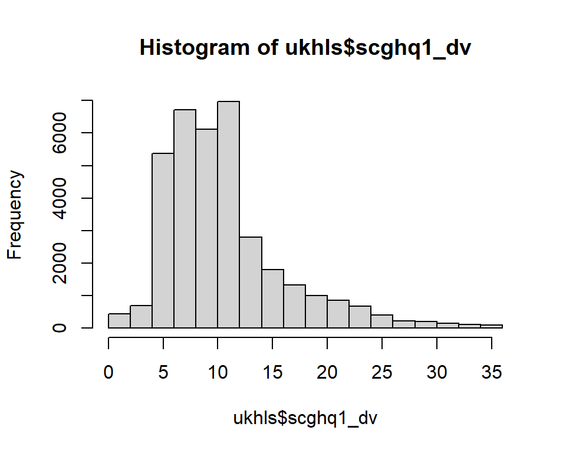

#### A frequency table of the “Whether in paid employment” variable:

```
In paid employment (employ) <categorical>
# total N=39293 valid N=37539 mean=1.43 sd=0.50

Value |     N | Raw % | Valid % | Cum. %
----------------------------------------
Yes   | 21276 | 54.15 |   56.68 |  56.68
No    | 16263 | 41.39 |   43.32 | 100.00
<NA>  |  1754 |  4.46 |    <NA> |   <NA>
```

#### A histogram of the “age” variable:

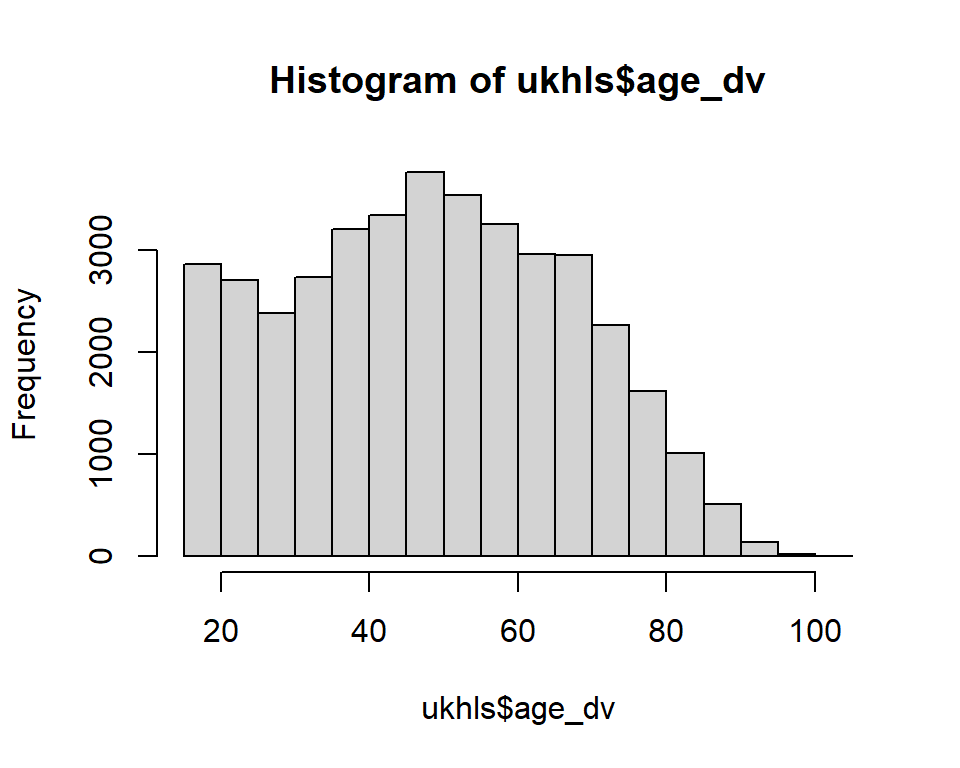

#### A frequency table of the “highest educational qualification” variable:

```
Highest qualification, UKHLS & BHPS samples (hiqual_dv) <categorical>
# total N=39293 valid N=38435 mean=3.07 sd=1.65

Value               |     N | Raw % | Valid % | Cum. %
------------------------------------------------------
Degree              | 10058 | 25.60 |   26.17 |  26.17
Other higher degree |  4659 | 11.86 |   12.12 |  38.29
A-level etc         |  8326 | 21.19 |   21.66 |  59.95
GCSE etc            |  7726 | 19.66 |   20.10 |  80.05
Other qualification |  3388 |  8.62 |    8.81 |  88.87
No qualification    |  4278 | 10.89 |   11.13 | 100.00
<NA>                |   858 |  2.18 |    <NA> |   <NA>
```

### Bivariate statistics - boxplot of wellbeing by employment:

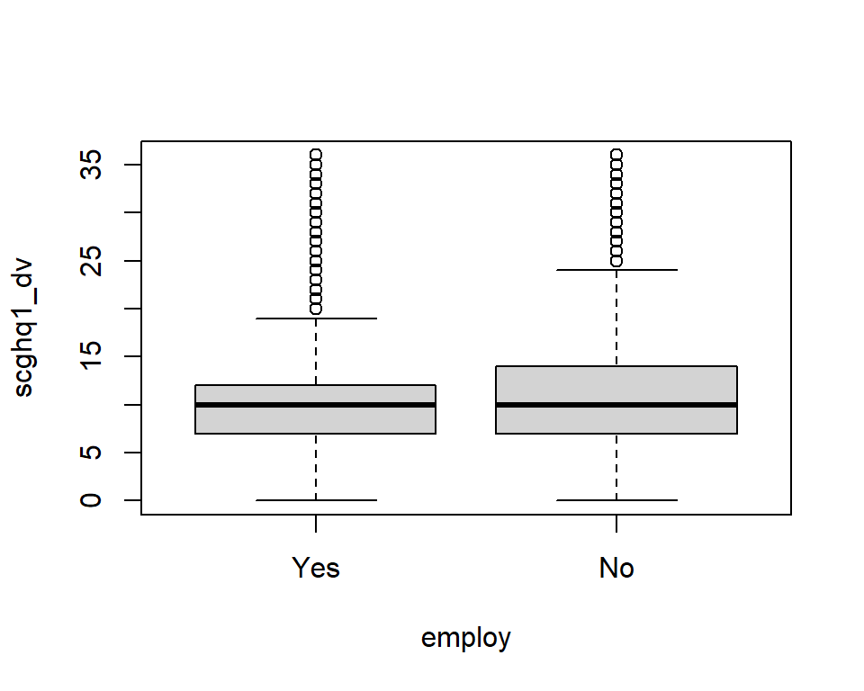

### Results from a multiple regression model:

```
MODEL INFO:
Observations: 35212 (4081 missing obs. deleted)
Dependent Variable: scghq1_dv
Type: OLS linear regression

MODEL FIT:
F(7,35204) = 75.285, p = 0.000
R² = 0.015
Adj. R² = 0.015

Standard errors: OLS
----------------------------------------------------------------------------
                                    Est.     2.5%    97.5%    t val.       p
------------------------------- -------- -------- -------- --------- -------
(Intercept)                       11.737   11.546   11.927   120.865   0.000
employNo                           1.214    1.084    1.345    18.299   0.000
age_dv                            -0.027   -0.031   -0.024   -15.161   0.000
hiqual_dvOther higher              0.194   -0.004    0.393     1.921   0.055
degree
hiqual_dvA-level etc               0.034   -0.134    0.202     0.396   0.692
hiqual_dvGCSE etc                  0.329    0.157    0.501     3.749   0.000
hiqual_dvOther                     0.436    0.205    0.667     3.697   0.000
qualification
hiqual_dvNo qualification          0.663    0.436    0.889     5.743   0.000
----------------------------------------------------------------------------
```

# How to prepare

The outputs above are very similar to the ones we produced in class in the IT labs. Therefore, the best way to prepare your answers is to revisit the Week 6-9 worksheets (available via the module’s Canvas page) and your class notes.

Make sure to engage with the Understanding Society website too. Particularly, [the variable search function on the Understanding Society website](https://www.understandingsociety.ac.uk/documentation/mainstage/dataset-documentation) can and should be used to gain insight into the meaning of variables beyond the description provided in the variable labels.

Engaging with the assigned readings would further help improve your understanding of the statistics in this exercise and help you provide a more accurate interpretation of the results.

**Recommended readings:**

- Agresti (2018): Chapters 10–11 (pp. 287–337)
- Gelman et al. (2020): Chapter 10 and Appendix B (pp. 131–150; 493–496)